# Revisao4

# Lista 6

1. A série temporal ibmclose (package: fma) é um exemplo clássico de uma série não estacionária. Use R para representar graficamente os preços diários para as acções IBM e a função ACF. Explique como cada gráfico mostra que a série não é estacionária e se deve ser diferenciada.

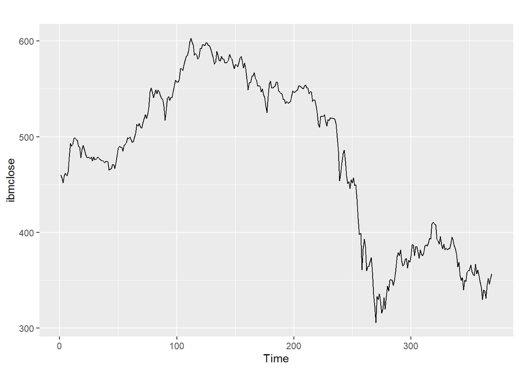

```r
autoplot(ibmclose)
```

A série apresenta uma tendência ascendente (Descendente depois de certo ponto) ao longo do tempo, o que é uma violação da estacionariedade que requer média constante.

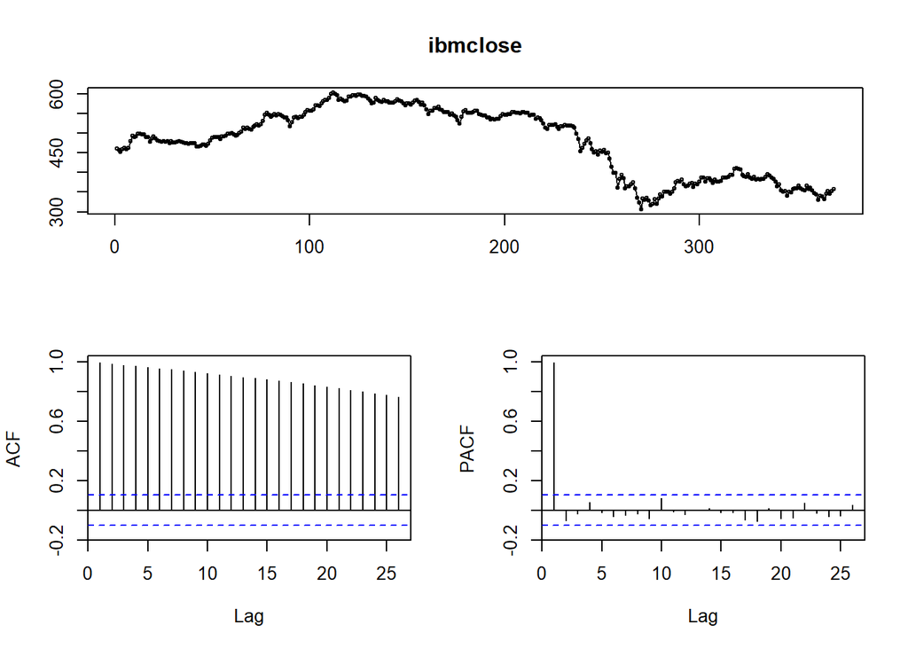

```r
tsdisplay(ibmclose)
```

As autocorrelações permanecem significativamente positivas por muitas defasagens, diminuindo gradualmente. Isso é típico de séries com tendência.

A série deve ser diferenciada para tentar remover a tendência e alcançar estacionariedade. Após diferenciação, a ACF deve ser reavaliada para verificar se o processo de diferenciação foi suficiente ou se diferenciações adicionais são necessárias.

2. Para as séries temporais abaixo, encontrar uma transformação Box-Cox apropriada, se necessário, e uma ordem de diferenciação a fim de obter dados estacionários.
1. usnetelec

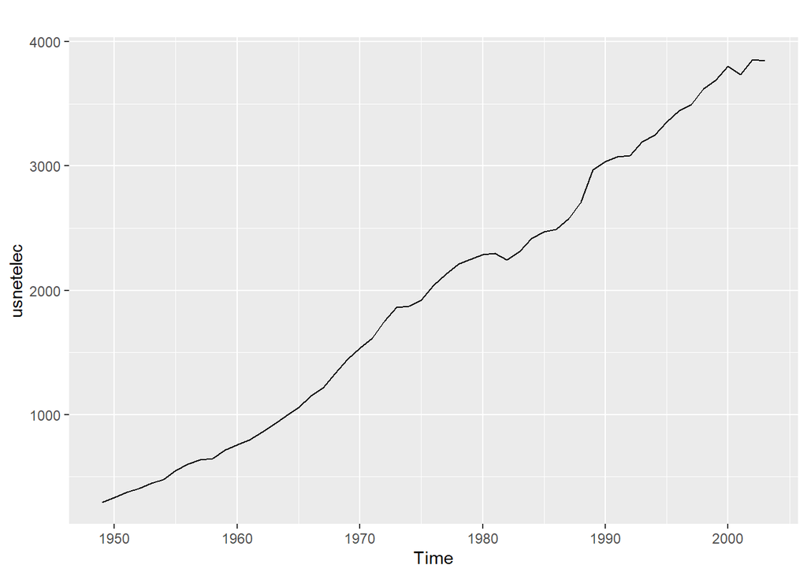

```r
autoplot(usnetelec)
```

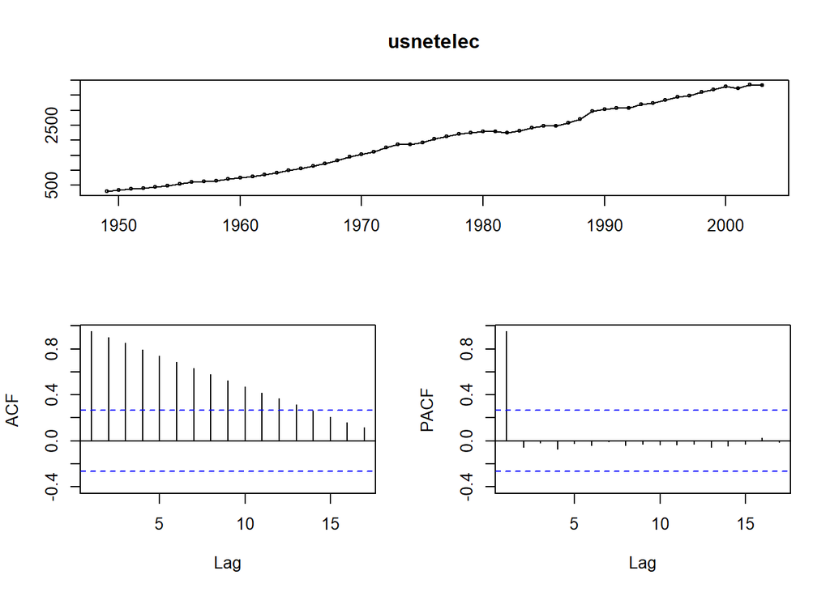

```r
tsdisplay(usnetelec)
```

```r
ndiffs(usnetelec)
```

[output not shown]

```r
diff2.usnetelec <- diff(usnetelec, differences = 2)
```

```r
adf.test(diff2.usnetelec)
```

```
##
##  Augmented Dickey-Fuller Test
##
## data:  diff2.usnetelec
## Dickey-Fuller = -5.5409, Lag order = 3, p-value = 0.01
## alternative hypothesis: stationary
```

Rejeitamos a hipótese nula de não-estacionariedade

2. usgdp

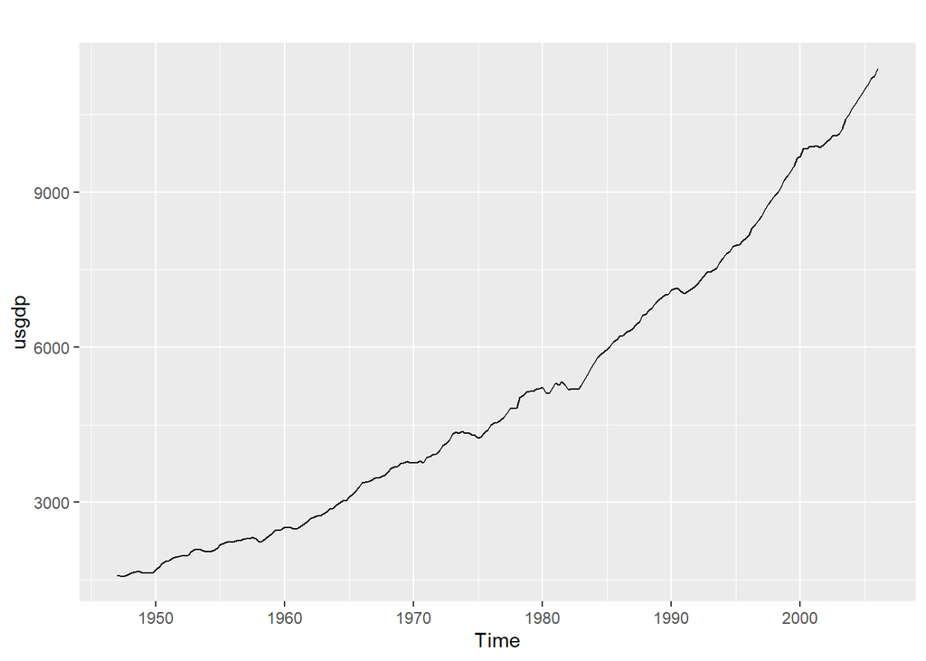

```r
autoplot(usgdp)
```

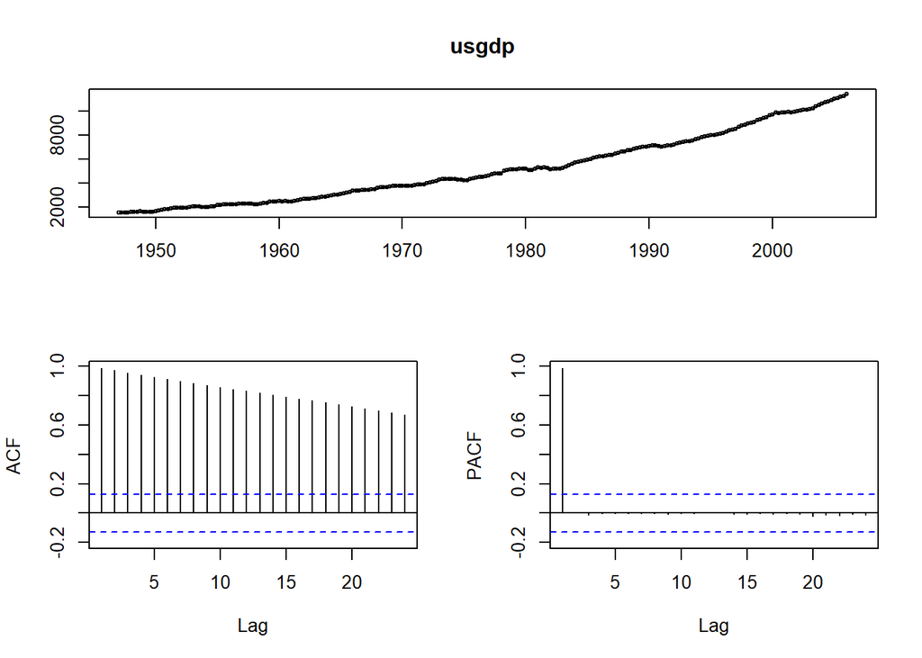

```r
tsdisplay(usgdp)
```

```r
ndiffs(usgdp)
```

```
## [1] 2
```

```r
diff2.usgdp <- diff(usgdp, differences = 2)
```

```r
adf.test(diff2.usgdp)
```

```
##
##  Augmented Dickey-Fuller Test
##
## data:  diff2.usgdp
## Dickey-Fuller = -7.8593, Lag order = 6, p-value = 0.01
## alternative hypothesis: stationary
```

Rejeitamos a hipótese nula de não-estacionariedade

3. mcopper

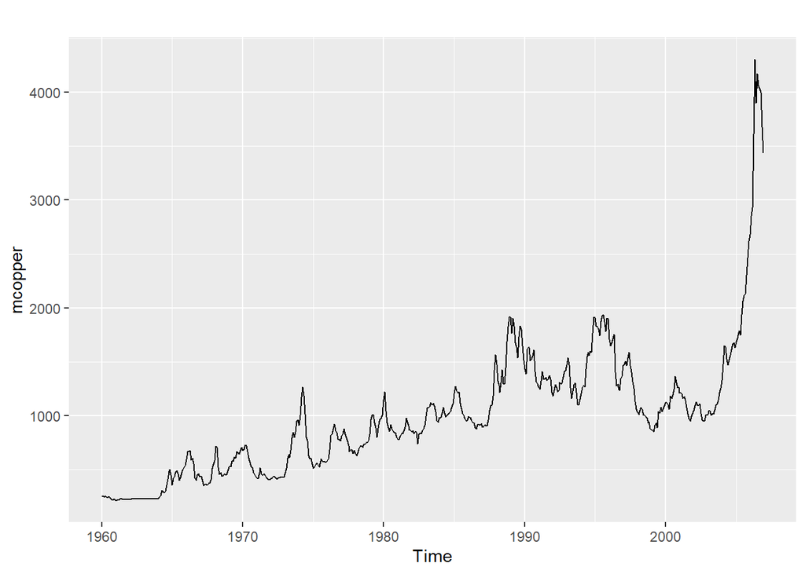

```r
autoplot(mcopper)
```

```r
ndiffs(mcopper)
```

```
## [1] 1
```

```r
diff.mcopper <- diff(mcopper)
```

```r
adf.test(diff.mcopper)
```

```
##
##  Augmented Dickey-Fuller Test
##
## data:  diff.mcopper
## Dickey-Fuller = -7.674, Lag order = 8, p-value = 0.01
## alternative hypothesis: stationary
```

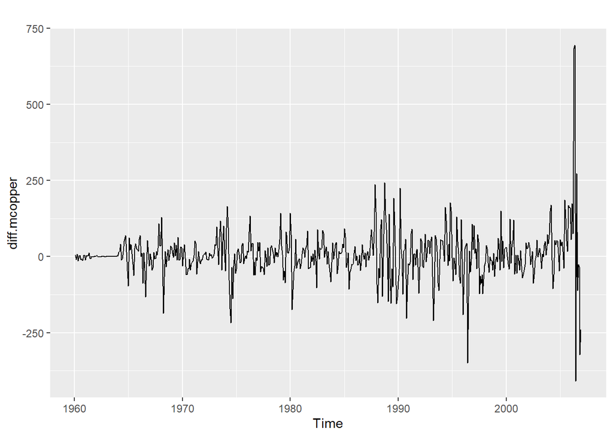

```r
autoplot(diff.mcopper)
```

4. enplanements

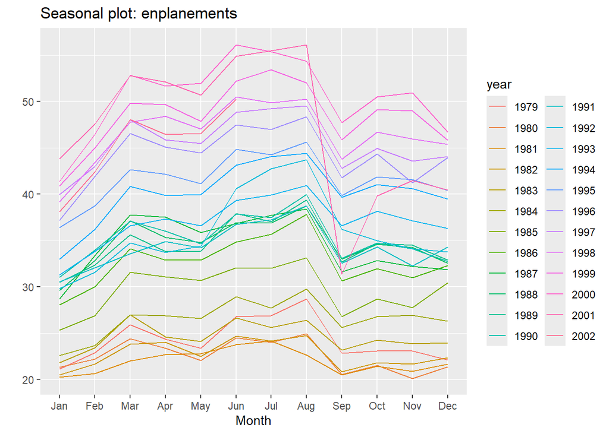

```r
ggseasonplot(enplanements)
```

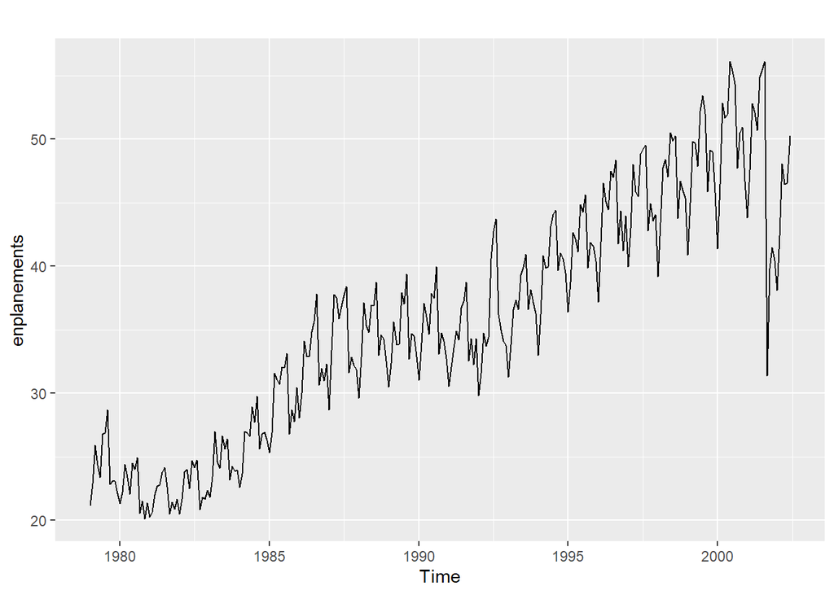

```r
autoplot(enplanements)
```

```r
nsdiffs(enplanements)
```

```
## [1] 1
```

```r
diff.enplanements <- diff(enplanements, lag = 12)
```

```r
adf.test(enplanements)
```

```
##
##  Augmented Dickey-Fuller Test
##
## data:  enplanements
## Dickey-Fuller = -4.7596, Lag order = 6, p-value = 0.01
## alternative hypothesis: stationary
```

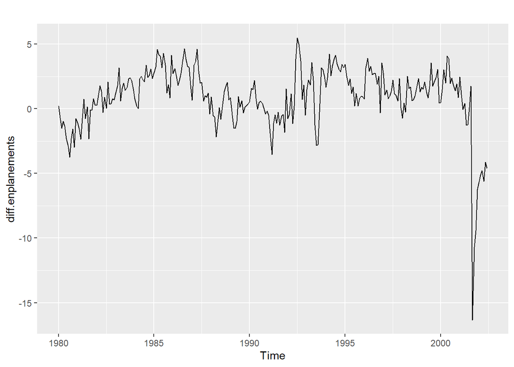

```r
autoplot(diff.enplanements)
```

```r
lambda_enplanements <- BoxCox.lambda(enplanements)
bc_enplanements <- BoxCox(enplanements, lambda = lambda_enplanements)
```

```r
bc.diff.enplanements <- diff(bc_enplanements)
```

```r
adf.test(bc.diff.enplanements)
```

```
##
##  Augmented Dickey-Fuller Test
##
## data:  bc.diff.enplanements
## Dickey-Fuller = -16.956, Lag order = 6, p-value = 0.01
## alternative hypothesis: stationary
```

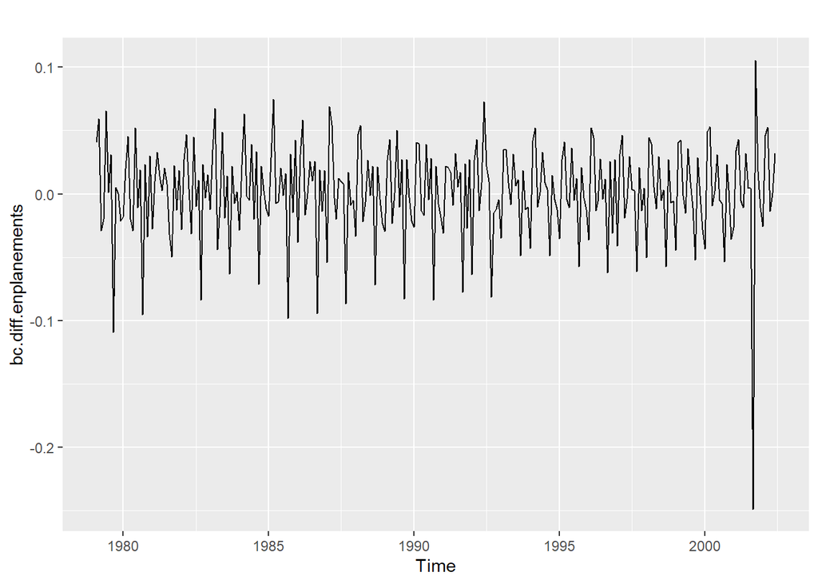

```r
autoplot(bc.diff.enplanements)
```

5. visitors

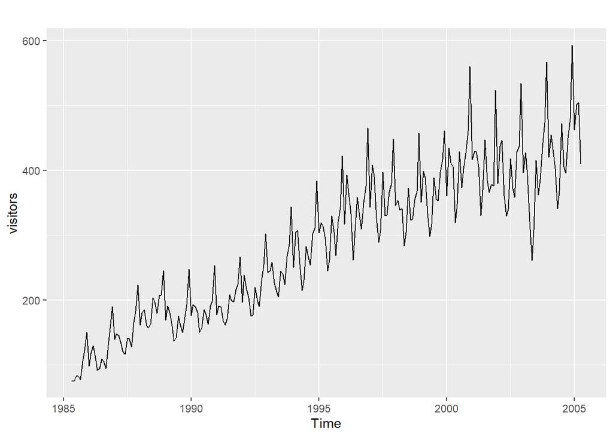

```r
autoplot(visitors)
```

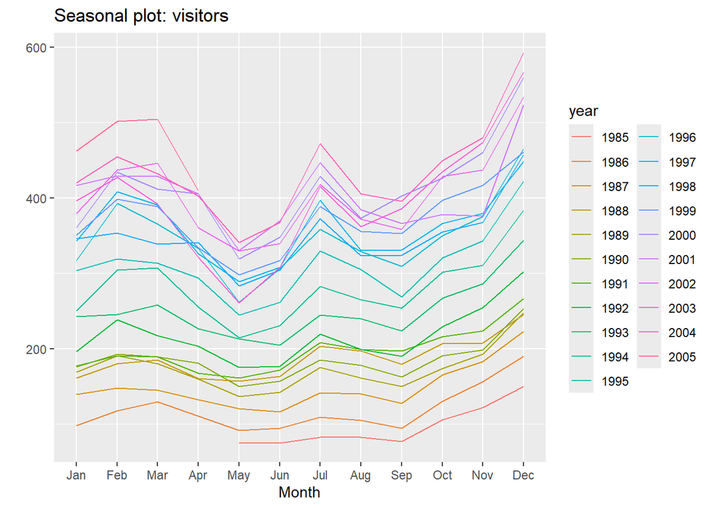

```r
ggseasonplot(visitors)
```

```r
lambda.visitors <- BoxCox.lambda(visitors)

bc.visitors <- BoxCox(visitors, lambda = lambda.visitors)

nsdiffs(bc.visitors)
```

```
## [1] 1
```

```r
diff.visitors <- diff(visitors, lag = 12)
```

```r
adf.test(visitors)
```

```
##
##  Augmented Dickey-Fuller Test
##
## data:  visitors
## Dickey-Fuller = -5.6928, Lag order = 6, p-value = 0.01
## alternative hypothesis: stationary
```

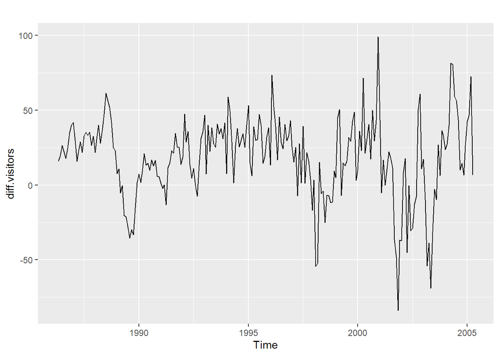

```r
autoplot(diff.visitors)
```

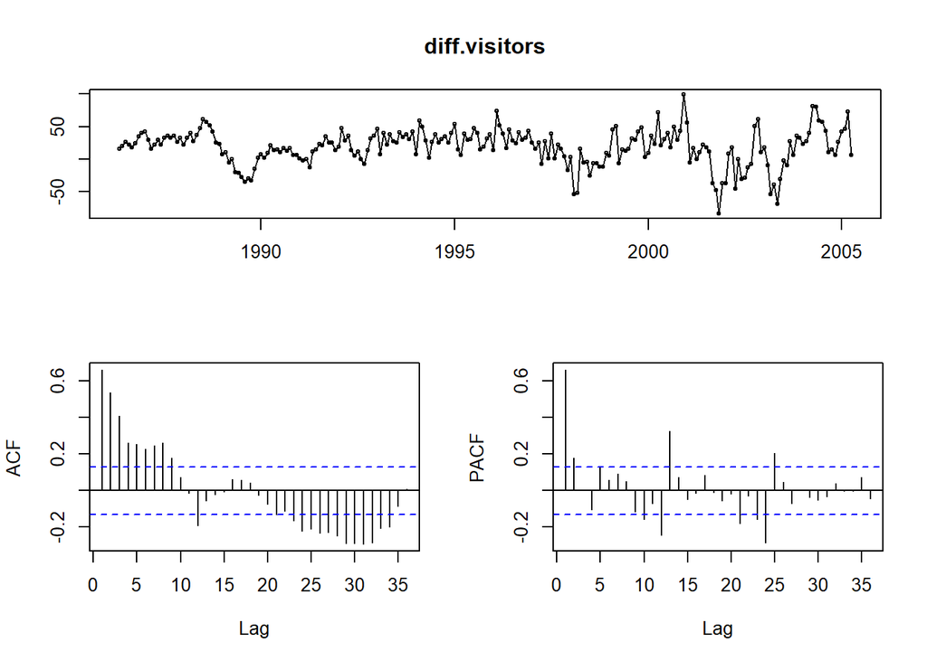

```r
tsdisplay(diff.visitors)
```

3. Para os dados NATURALGAS (pasta Dados na tutoria), encontre a ordem apropriada de diferenciação (após transformação, se necessário) para obter dados estacionários.

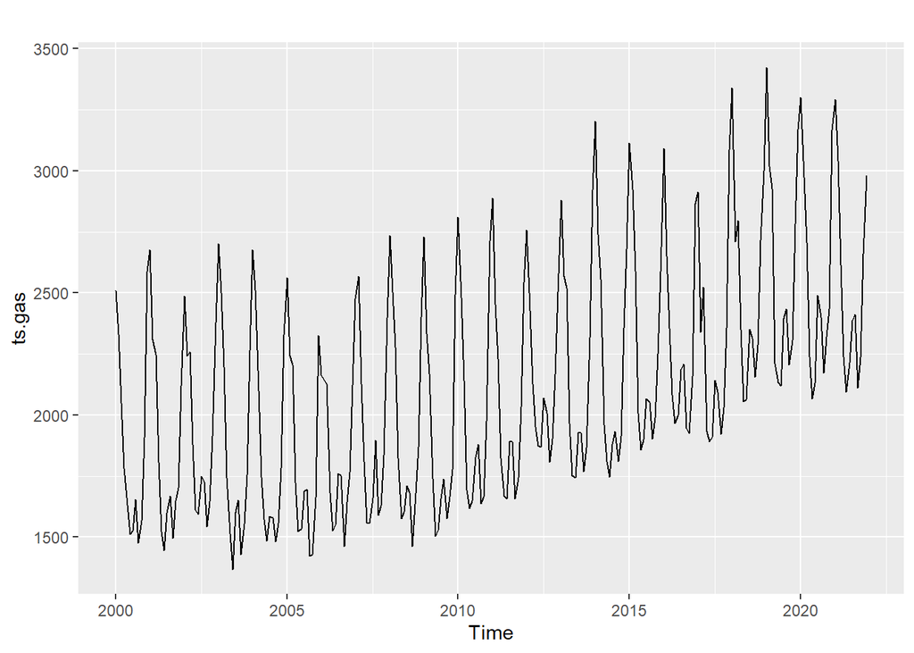

```r
autoplot(ts.gas)
```

```r
nsdiffs(ts.gas)
```

```
## [1] 1
```

```r
diff.ts.gas <- diff(ts.gas, lag = 12)
```

```r
adf.test(diff.ts.gas)
```

```
##
##  Augmented Dickey-Fuller Test
##
## data:  diff.ts.gas
## Dickey-Fuller = -5.1273, Lag order = 6, p-value = 0.01
## alternative hypothesis: stationary
```

$H_0$: A série temporal não é estacionária vs $H_1$: A série temporal é estacionária

O valor-p do teste DF foi igual a 0.01, sendo assim menor do qeu 0.05. Ou seja, considerando o nível de signofocância $\alpha=5\%$ rejeitamos a hipótese nula, sendo assim, a série é estacionária.

# Lista 7

1. Considere os dados usgdp (package expsmooth).
1. Se necessário, encontrar uma transformação Box-Cox adequada para os dados.

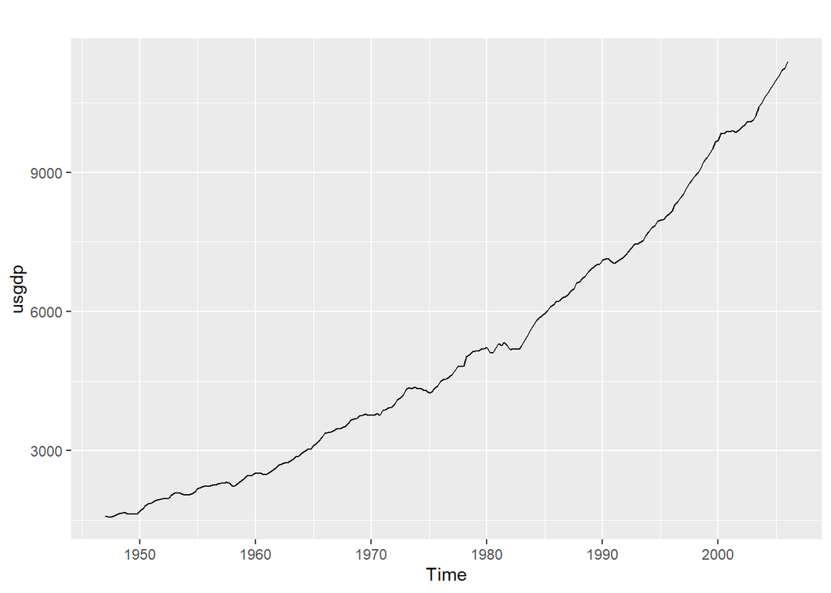

```r
autoplot(usgdp)
```

2. Ajuste um modelo ARIMA adequado aos dados da alínea anterior utilizando auto.arima(). Indique o modelo e seus coeficientes.

```r
auto.usgdp <- auto.arima(usgdp)
```

[output not shown]

3. Faça o diagnóstico aos resíduos.

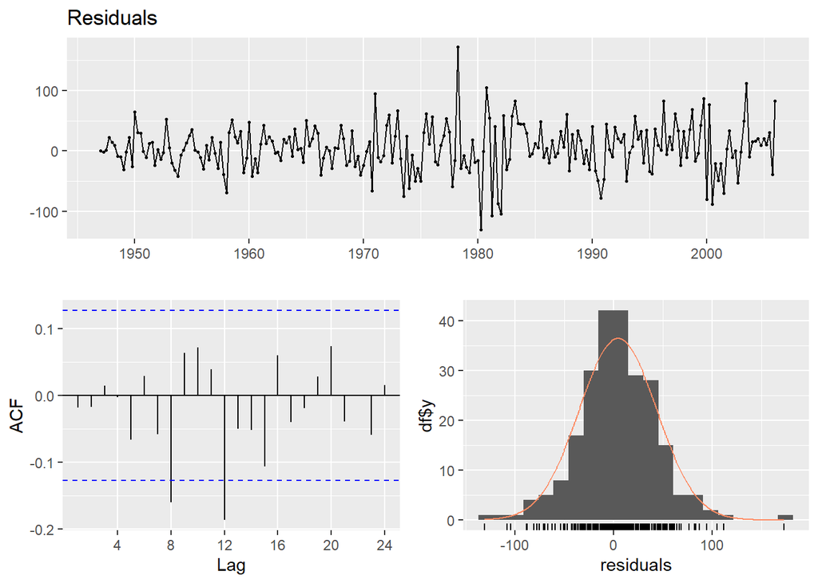

```
##
##  Ljung-Box test
##
## data:  Residuals
## Q* = 8.6247, df = 8, p-value = 0.3749
##
## Model df: 0.   Total lags used: 8
```

```r
checkresiduals(auto.usgdp$residuals)
```

Os resíduos parecem ser ruído branco

4. Experimente outros modelos plausíveis, experimentando várias ordens.

```r
ndiffs(usgdp)
```

```
## [1] 2
```

Arima(p, 2, q)

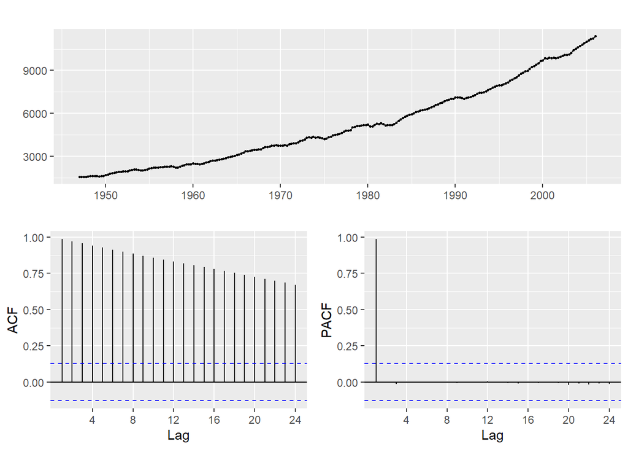

```r
ggtsdisplay(usgdp)
```

```r
(fit.021 <- Arima(usgdp, order = c(0,2,1)))
```

```
## Series: usgdp
## ARIMA(0,2,1)
##
## Coefficients:
##           ma1
##       -0.7139
## s.e.   0.0758
##
## sigma^2 = 1747:  log likelihood = -1210.49
## AIC=2424.98   AICc=2425.03   BIC=2431.9
```

```r
(fit.120 <- Arima(usgdp, order = c(1,2,0)))
```

```
## Series: usgdp
## ARIMA(1,2,0)
##
## Coefficients:
##           ar1
##       -0.4810
## s.e.   0.0577
##
## sigma^2 = 1892:  log likelihood = -1219.67
## AIC=2443.35   AICc=2443.4   BIC=2450.27
```

```r
(fit.121 <- Arima(usgdp, order = c(1,2,1)))
```

```
## Series: usgdp
## ARIMA(1,2,1)
##
## Coefficients:
##          ar1      ma1
##       0.2899  -0.9555
## s.e.  0.0668   0.0197
##
## sigma^2 = 1665:  log likelihood = -1204.96
## AIC=2415.92   AICc=2416.02   BIC=2426.3
```

```r
(fit.122 <- Arima(usgdp, order = c(1,2,2)))
```

```
## Series: usgdp
## ARIMA(1,2,2)
##
## Coefficients:
##          ar1      ma1     ma2
##       0.6539  -1.3426  0.3636
## s.e.  0.1174   0.1347  0.1277
##
## sigma^2 = 1631:  log likelihood = -1201.96
## AIC=2411.92   AICc=2412.09   BIC=2425.76
```

```r
(fit.123 <- Arima(usgdp, order = c(1,2,3)))
```

```
## Series: usgdp
## ARIMA(1,2,3)
##
## Coefficients:
##          ar1      ma1     ma2      ma3
##       0.3331  -1.0459  0.2635  -0.1768
## s.e.  0.2754   0.2745  0.2048   0.0902
##
## sigma^2 = 1613:  log likelihood = -1200.17
## AIC=2410.33   AICc=2410.59   BIC=2427.63
```

```r
(fit.124 <- Arima(usgdp, order = c(1,2,4)))
```

```
## Series: usgdp
## ARIMA(1,2,4)
##
## Coefficients:
##          ar1      ma1     ma2      ma3     ma4
##       0.5171  -1.2298  0.3977  -0.1902  0.0518
## s.e.  0.3896   0.3933  0.2983   0.0992  0.1141
##
## sigma^2 = 1618:  log likelihood = -1200.07
## AIC=2412.14   AICc=2412.51   BIC=2432.9
```

```r
(fit.221 <- Arima(usgdp, order = c(2,2,1))) #Melhor
```

```
## Series: usgdp
## ARIMA(2,2,1)
##
## Coefficients:
##          ar1     ar2      ma1
##       0.2421  0.2074  -0.9666
## s.e.  0.0664  0.0662   0.0153
##
## sigma^2 = 1606:  log likelihood = -1200.13
## AIC=2408.25   AICc=2408.43   BIC=2422.09
```

```r
(fit.223 <- Arima(usgdp, order = c(2,2,3)))
```

```
## Series: usgdp
## ARIMA(2,2,3)
##
## Coefficients:
##           ar1     ar2      ma1      ma2     ma3
##       -0.1344  0.3703  -0.5748  -0.4357  0.0571
## s.e.   0.2253  0.1710   0.2366   0.2726  0.1556
##
## sigma^2 = 1611:  log likelihood = -1199.5
## AIC=2411   AICc=2411.37   BIC=2431.76
```

5. Escolha o melhor modelo ARIMA com base no critério de AIC e faça um diagnóstico aos residuos.

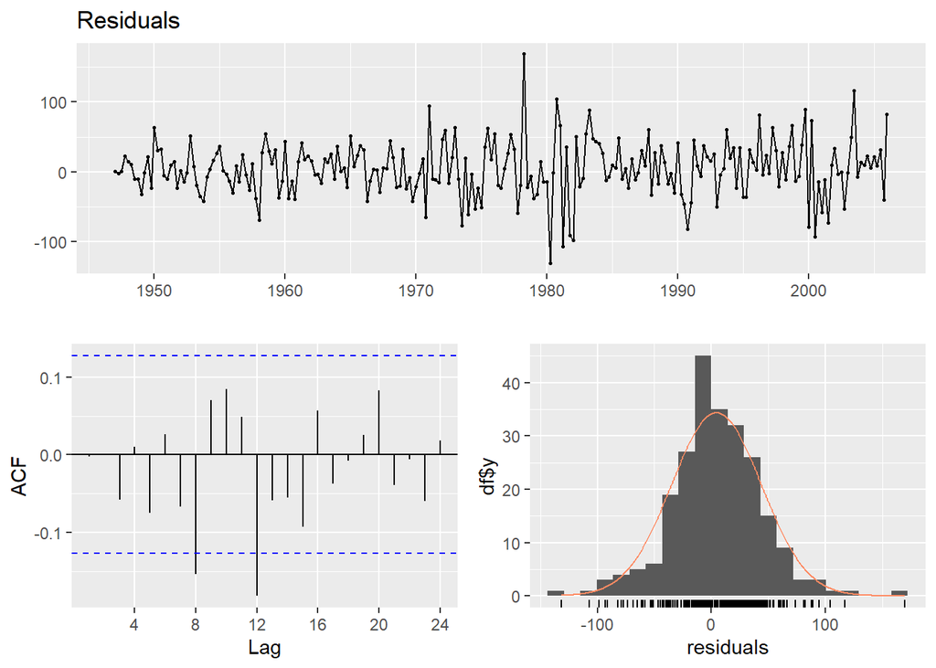

```
##
##  Ljung-Box test
##
## data:  Residuals
## Q* = 9.362, df = 8, p-value = 0.3127
##
## Model df: 0.   Total lags used: 8
```

```r
checkresiduals(fit.221$residuals)
```

6. Averigue o modelo acima em relação à estacionaridade e invertibilidade.

Coefficients: ar1 ar2 ma1 0.2421 0.2074 -0.9666 s.e. 0.0664 0.0662 0.0153

É Estacionária e Invertível

7. Obtenha as previsões (h=20) para o seu modelo ajustado. Serão as previsões razoáveis?

```r
for.usgdp <- forecast(fit.221, h = 20)
```

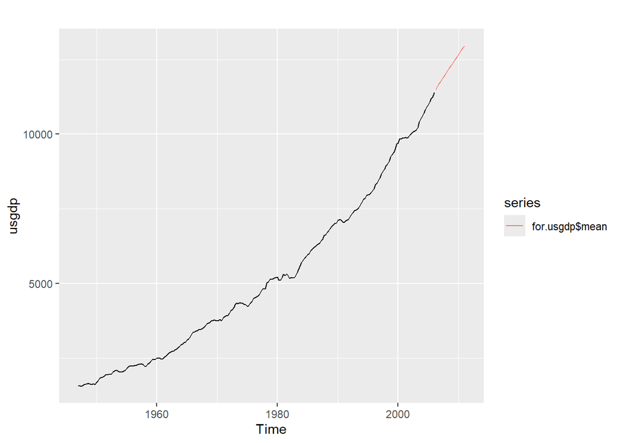

```r
autoplot(usgdp)+
  autolayer(for.usgdp$mean)
```

8. Compare o resultado acima com o que obteria utilizando a função ets() (sem transformação).

```r
ets.usgdp <- ets(usgdp)
for.ets.usgdp <- forecast(ets.usgdp, h = 20)
```

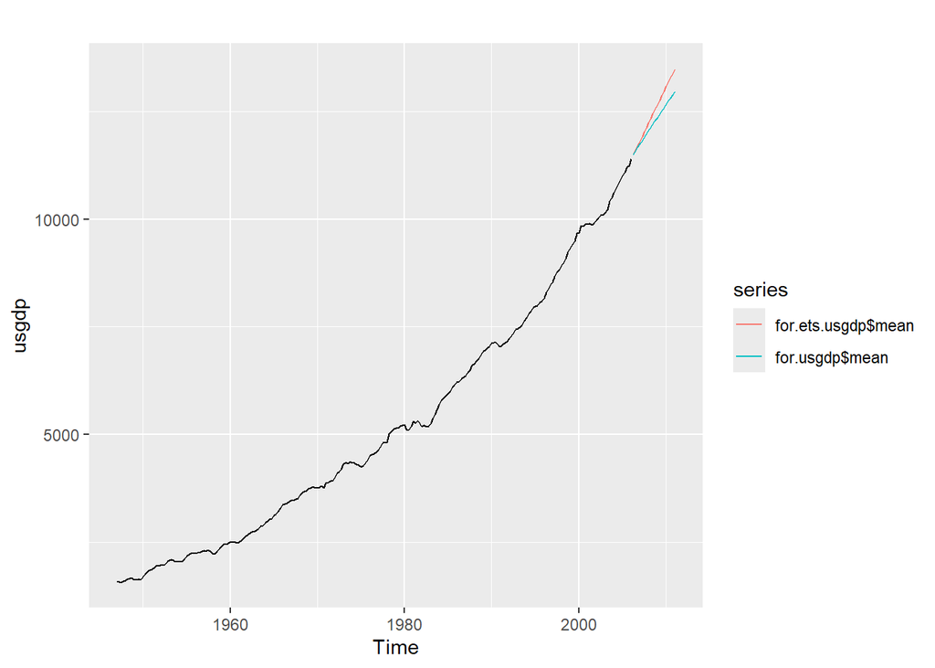

```r
autoplot(usgdp)+
  autolayer(for.ets.usgdp$mean)+
  autolayer(for.usgdp$mean)
```

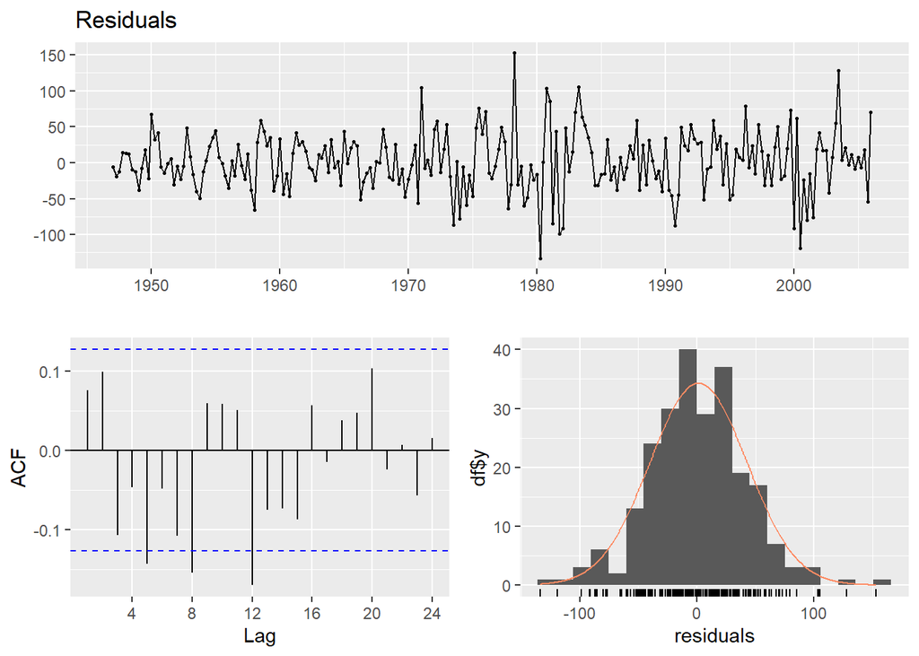

```
##
##  Ljung-Box test
##
## data:  Residuals
## Q* = 21.461, df = 8, p-value = 0.006018
##
## Model df: 0.   Total lags used: 8
```

```r
checkresiduals(ets.usgdp$residuals)
```

Há autocorrelação nos resíduos, logo, a previsão não é confiável

2. Consideremos os dados wmurders (package: fpp2), o número de mulheres assassinadas anualmente (por 100.000 habitantes) nos Estados Unidos.
1. Ao estudar os gráficos apropriados desta série temporal, encontre um modelo ARIMA(p,d,q) apropriado a estes dados com base no critério AIC.

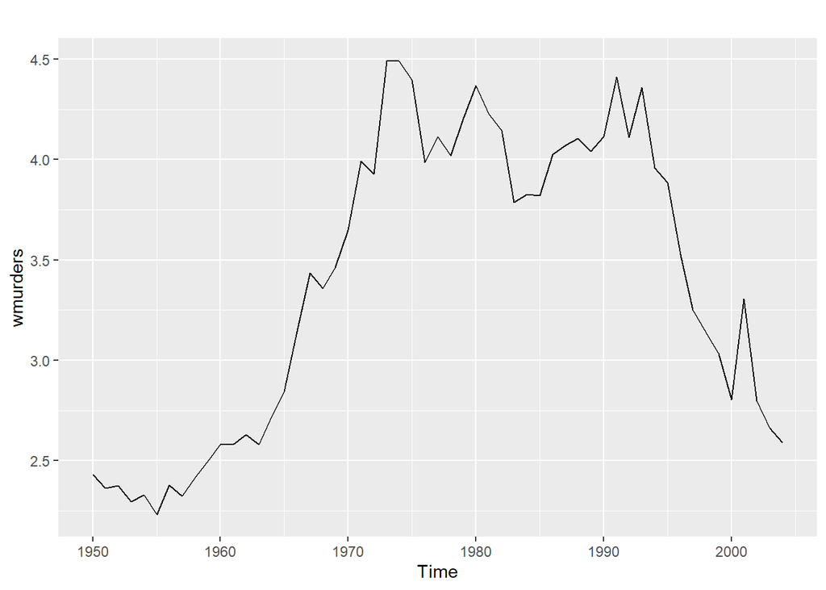

```r
autoplot(wmurders)
```

```r
ndiffs(wmurders)
```

```
## [1] 2
```

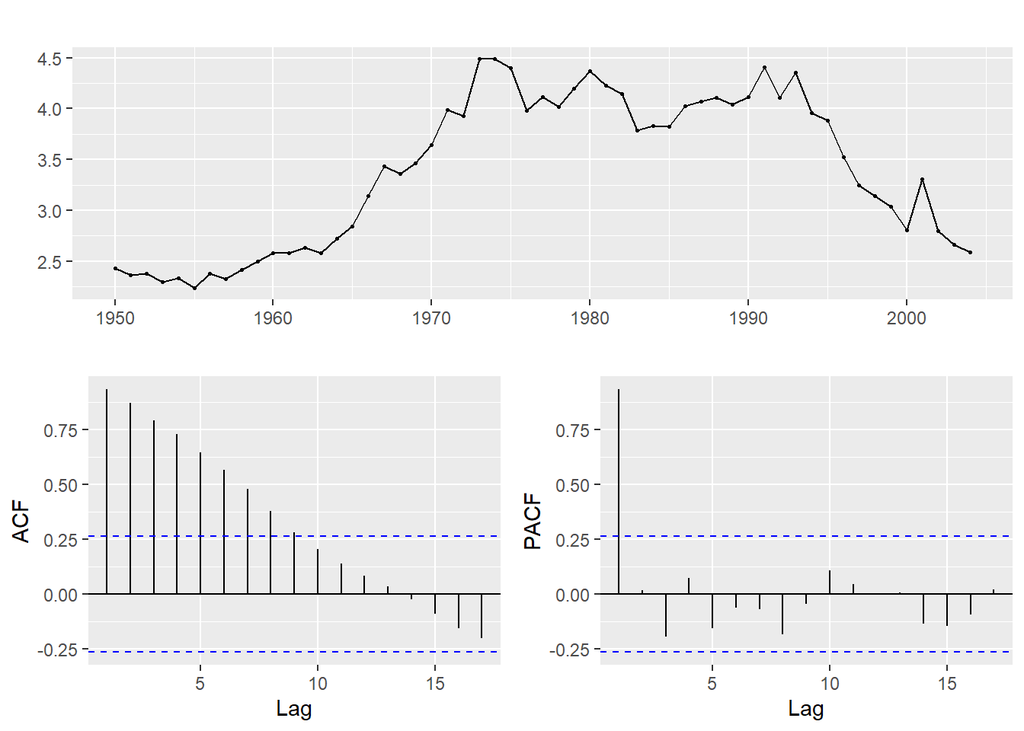

```r
ggtsdisplay(wmurders)
```

```r
(fit.021.w <- arima(wmurders, order = c(0,2,1)))
```

```
##
## Call:
## arima(x = wmurders, order = c(0, 2, 1))
##
## Coefficients:
##           ma1
##       -0.8995
## s.e.   0.0669
##
## sigma^2 estimated as 0.04657:  log likelihood = 5.24,  aic = -6.48
```

```r
(fit.121.w <- arima(wmurders, order = c(1,2,1)))
```

```
##
## Call:
## arima(x = wmurders, order = c(1, 2, 1))
##
## Coefficients:
##           ar1      ma1
##       -0.2434  -0.8261
## s.e.   0.1553   0.1143
##
## sigma^2 estimated as 0.04457:  log likelihood = 6.44,  aic = -6.88
```

```r
(fit.221.w <- arima(wmurders, order = c(2,2,1))) # Melhor
```

```
##
## Call:
## arima(x = wmurders, order = c(2, 2, 1))
##
## Coefficients:
##           ar1     ar2      ma1
##       -0.1247  0.2348  -0.9082
## s.e.   0.1612  0.1560   0.0866
##
## sigma^2 estimated as 0.04262:  log likelihood = 7.56,  aic = -7.12
```

```r
(fit.321.w <- arima(wmurders, order = c(3,2,1)))
```

```
##
## Call:
## arima(x = wmurders, order = c(3, 2, 1))
##
## Coefficients:
##           ar1     ar2      ar3      ma1
##       -0.1288  0.2029  -0.0765  -0.8888
## s.e.   0.1634  0.1701   0.1538   0.1025
##
## sigma^2 estimated as 0.04242:  log likelihood = 7.68,  aic = -5.36
```

```r
(fit.222.w <- arima(wmurders, order = c(2,2,2)))
```

```
##
## Call:
## arima(x = wmurders, order = c(2, 2, 2))
##
## Coefficients:
##           ar1     ar2      ma1      ma2
##       -0.3200  0.1947  -0.7027  -0.1776
## s.e.   0.5955  0.2161   0.6029   0.5089
##
## sigma^2 estimated as 0.0425:  log likelihood = 7.63,  aic = -5.26
```

2. Examine os resíduos. Será o modelo satisfatório?

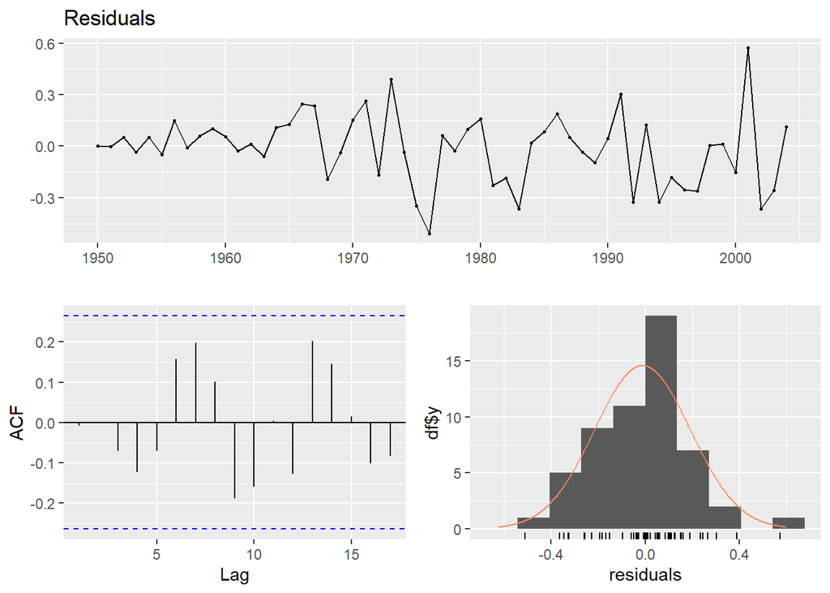

```
##
##  Ljung-Box test
##
## data:  Residuals
## Q* = 10.519, df = 10, p-value = 0.3962
##
## Model df: 0.   Total lags used: 10
```

```r
checkresiduals(fit.221.w$residuals)
```

Não rejeitamos a hipótese nula, logo os resíduos são ruído branco

3. Obtenha as previsões a três passos à frente (h=3).

```r
for.w <- forecast(fit.221.w, h = 3)
```

4. Crie um gráfico da série temporal com as previsões e os intervalos de previsão para h=3.

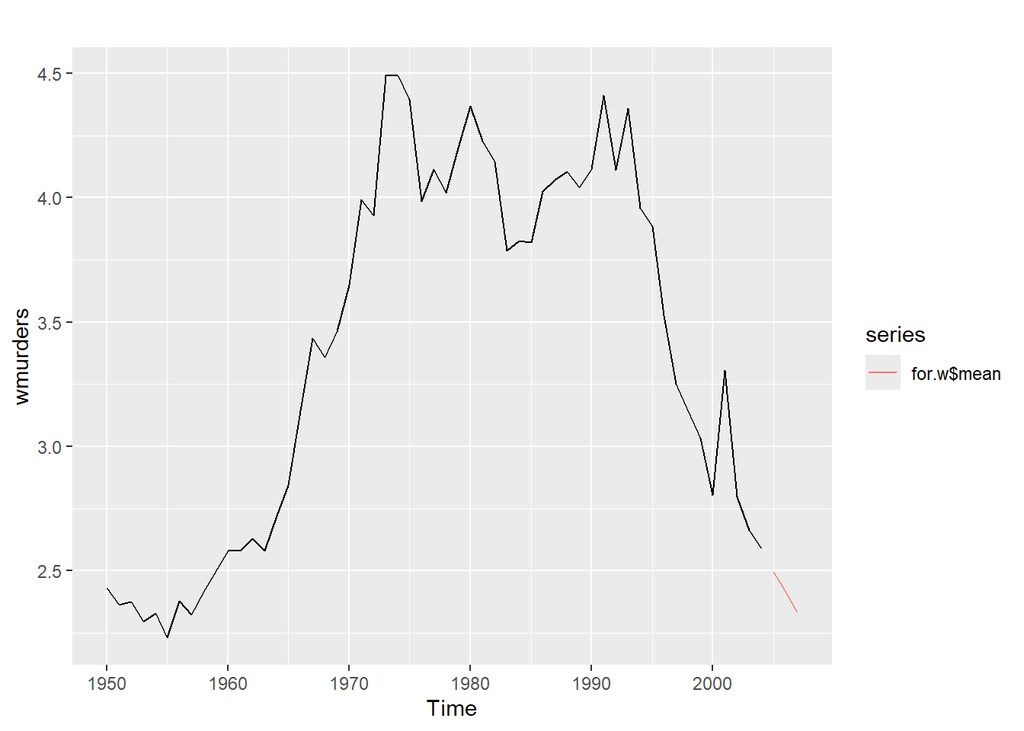

```r
autoplot(wmurders)+
  autolayer(for.w$mean)
```

5. Será que a função auto.arima() dá o mesmo modelo? Se não o for, qual o modelo que acha que é melhor?

```r
(auto.arima(wmurders))
```

```
## Series: wmurders
## ARIMA(1,2,1)
##
## Coefficients:
##           ar1      ma1
##       -0.2434  -0.8261
## s.e.   0.1553   0.1143
##
## sigma^2 = 0.04632:  log likelihood = 6.44
## AIC=-6.88   AICc=-6.39   BIC=-0.97
```

Não dá o mesmo modelo, e ele também não é melhor

3. Considere os dados austourists (package: fpp2), o total de dormidas, por trimestres, de turistas internacionais na Austrália para o período 1999-2015.
1. Separe os últimos 2 anos e coloque-os num objecto designado por aus.test. Os restantes coloque em aus.train.

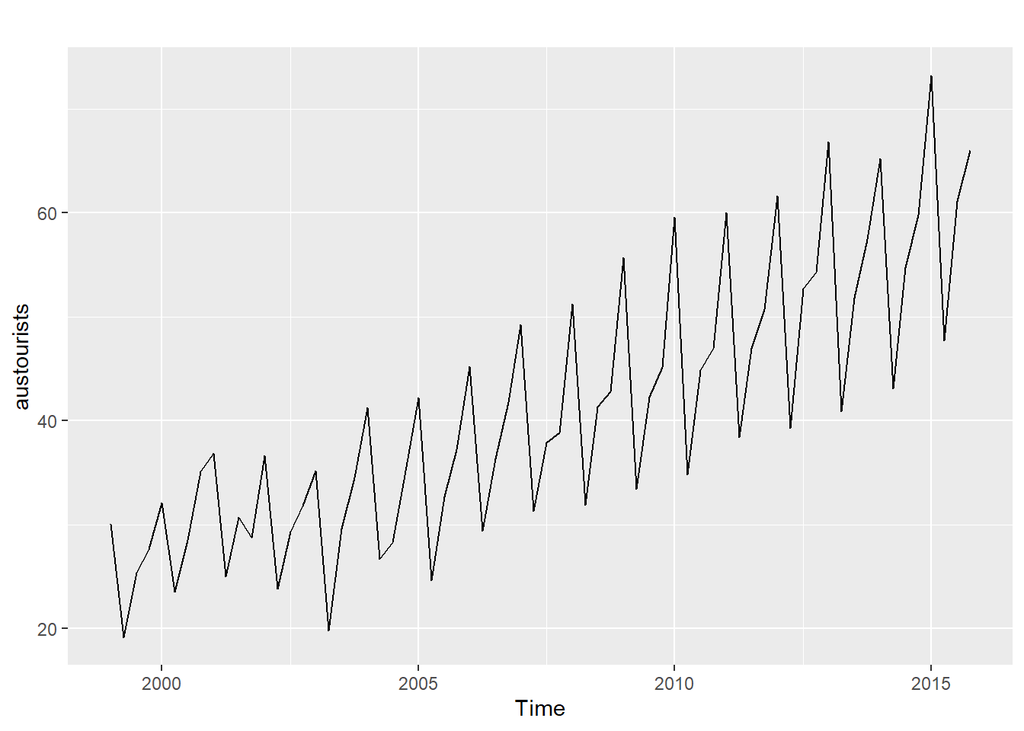

```r
autoplot(austourists)
```

```r
tail(austourists)
```

```
##          Qtr1     Qtr2     Qtr3     Qtr4
## 2014                   54.76076 59.83447
## 2015 73.25703 47.69662 61.09777 66.05576
```

```r
aus.treino <- window(austourists, end = c(2013,4))
aus.teste <- window(austourists, start = c(2014,1))
length(aus.treino)
```

```
## [1] 60
```

```r
length(aus.teste)
```

```
## [1] 8
```

2. Represente os dados de treino graficamente e comente.

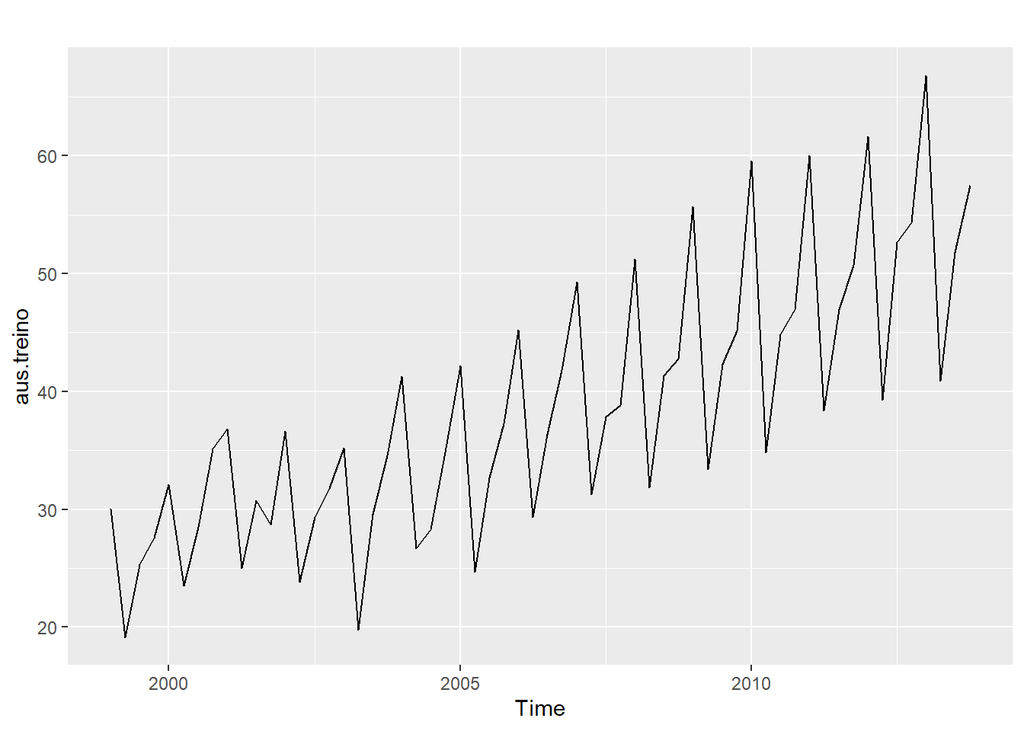

```r
autoplot(aus.treino)
```

3. Será que os dados precisam de ser transformados? Em caso afirmativo, encontrar uma transformação adequada.

Não há necessidade

4. O que podemos observar no gráfico ACF?

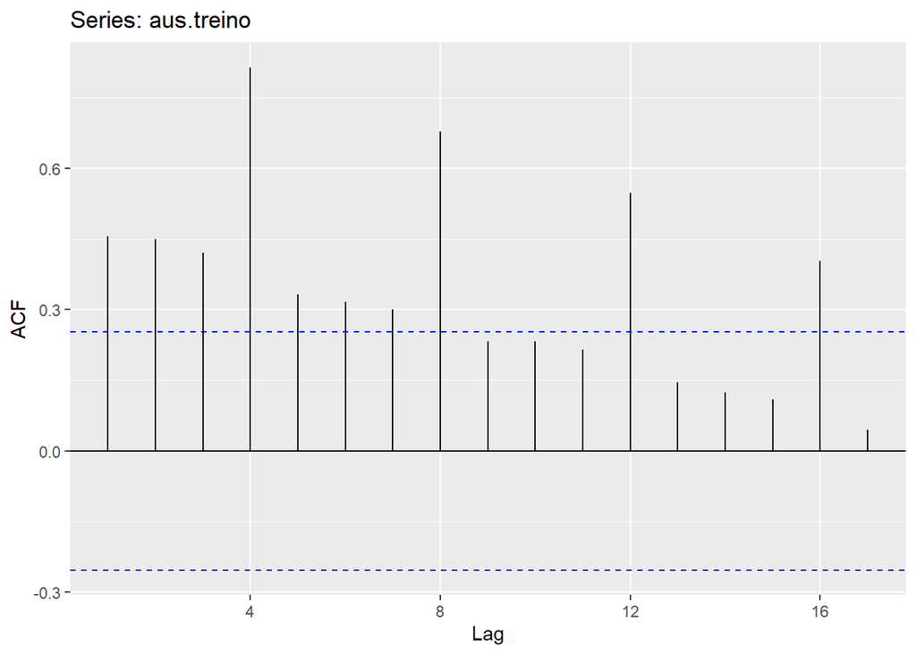

```r
ggAcf(aus.treino)
```

O decaimento lento da ACF é típico de séries não estacionárias. Picos regulares em lags 4, 8, 12, 16 sugerem um ciclo sazonal

5. O que podemos observar no gráfico PACF?

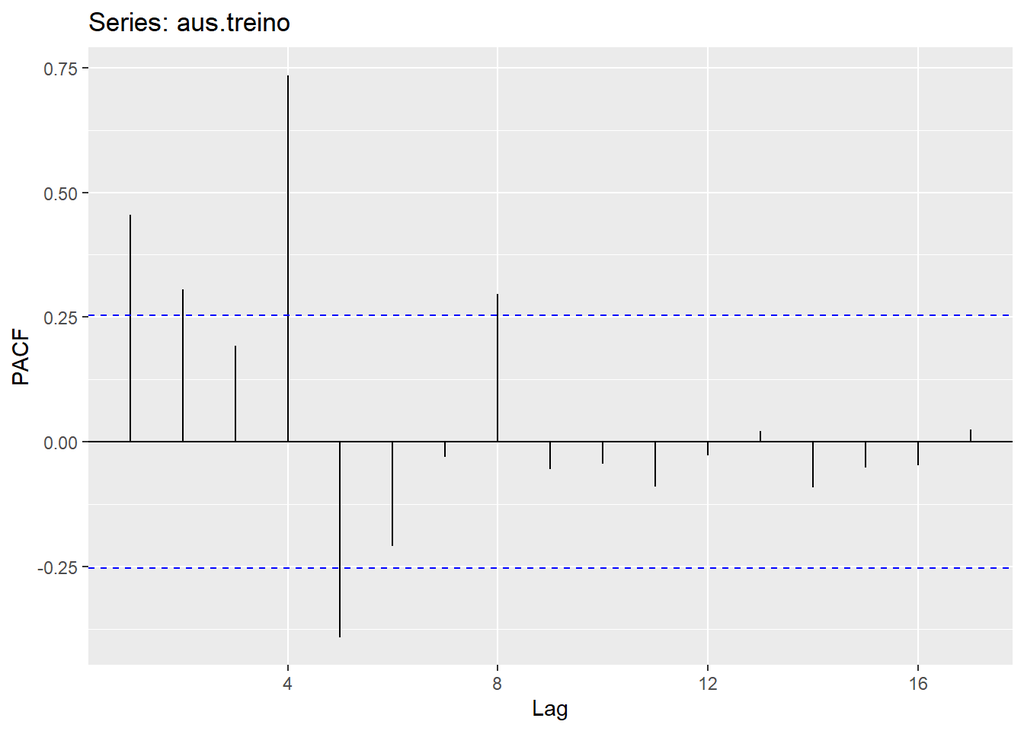

```r
ggPacf(aus.treino)
```

6. Use a função auto.arima() para ajustar um modelo aos dados.

```r
(auto.aus <- auto.arima(aus.treino))
```

```
## Series: aus.treino
## ARIMA(1,0,0)(1,1,0)[4] with drift
##
## Coefficients:
##          ar1     sar1   drift
##       0.4058  -0.4772  0.5053
## s.e.  0.1255   0.1216  0.0852
##
## sigma^2 = 5.165:  log likelihood = -124.49
## AIC=256.98   AICc=257.76   BIC=265.08
```

7. Use a função ets() para ajustar um modelos aos dados.

```r
ets.aus <- ets(aus.treino)
```

8. Através de qual dos modelos se obtem o melhor ajuste? Use a medida de erro RMSE.

```r
accuracy(ets.aus)[,c("RMSE")]
```

```
## [1] 1.966538
```

```r
accuracy(auto.aus)[,c("RMSE")]
```

```
## [1] 2.136067
```

ETS é o melhor modelo para aus.treino segundo o RMSE.

1. Obtenha as previsões para ambos os modelos. Será que o melhor modelo é também aquele cujas previsões são as mais próximas dos valores reais (dados de teste)? Use a medida de erro RMSE.

```r
for.ets <- forecast(ets.aus, h = 8)$mean
for.arima <- forecast(auto.aus, h = 8)$mean
```

```r
accuracy(for.ets, aus.teste)[,c("RMSE")]
```

```
## [1] 2.989673
```

```r
accuracy(for.arima, aus.teste)[,c("RMSE")]
```

```
## [1] 2.865348
```

Na validação dentro da amostra, o ETS era melhor.

Nos dados de teste, o ARIMA teve menor erro.

4. Considere os dados usmelec(package: fpp2), a produção mensal de electricidade (em mil milhões de kilowatts-hora) no período de Janeiro de 1973 - Junho de 2013.
1. Represente os dados graficamente e comente.

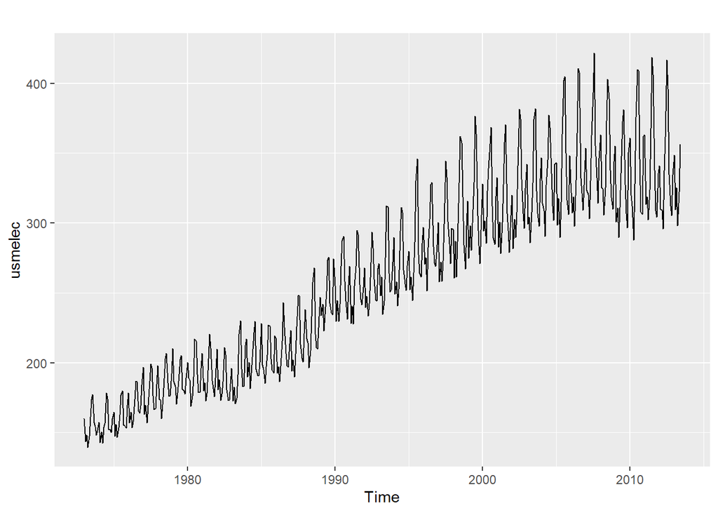

```r
autoplot(usmelec)
```

A série claramente não é estacionária devido à tendência marcante. Sugere-se diferenciação para análise posterior.

2. Use um gráfico adequado para observar em que periodo(s) há maior produção de electricidade.

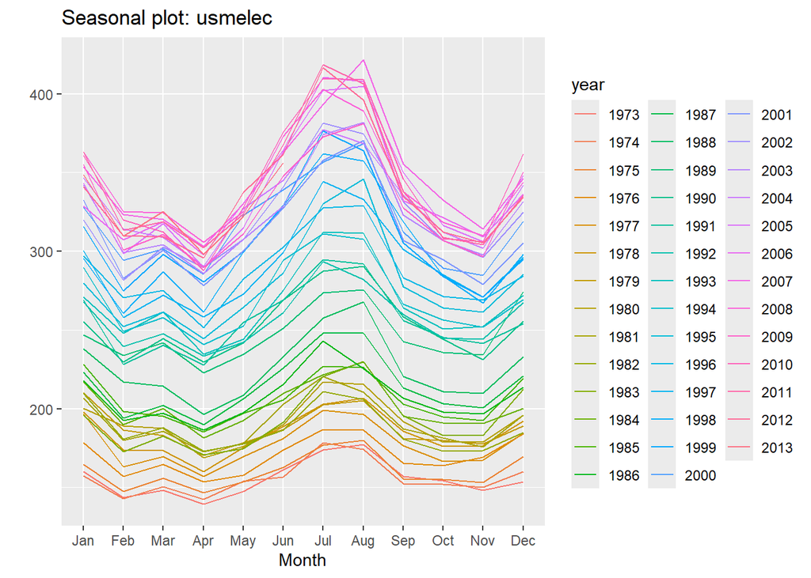

```r
ggseasonplot(usmelec)
```

Os meses de maior uso de energia, como natural, são os do verão do hemisfério norte, julho e agosto

3. Examine a média móvel de 12 meses desta série para ver que tipo de tendência está envolvida.

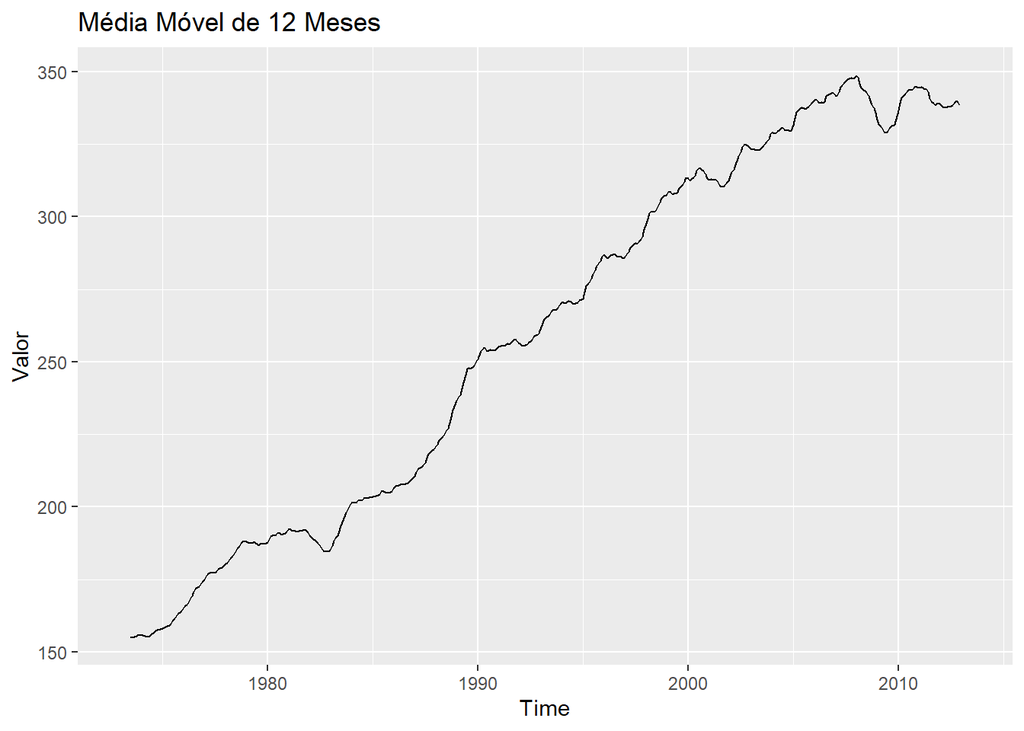

```r
media_movel <- ma(usmelec, order = 12)
autoplot(media_movel) +
  labs(title = "Média Móvel de 12 Meses", y = "Valor")
```

4. Será que os dados precisam de ser transformados? Em caso afirmativo, encontre uma transformação adequada.

```r
lambda <- BoxCox.lambda(usmelec)
bc.usmelec <- BoxCox(usmelec, lambda)
```

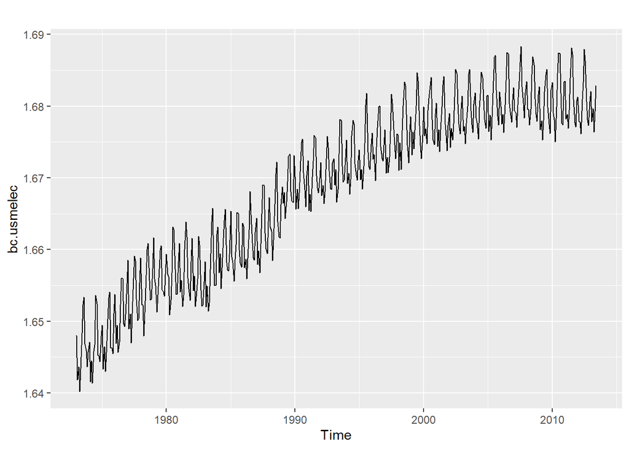

```r
autoplot(bc.usmelec)
```

5. Será que os dados estão estacionários? Se não, encontre uma diferenciação adequada que produza dados estacionários.

```r
nsdiffs(bc.usmelec)
```

```
## [1] 1
```

```r
diff.bc.usmelec <- diff(bc.usmelec)
```